# R Notebook

Introduction of package ClusterR. Documentation can be found at https://cran.r-project.org/web/packages/ClusterR/vignettes/the_clusterR_package.html.

—> dataset sintetici 2d per visualizzazioni punti generati da gaussiane punti generati da PCA di un dataset grande -> proteine?

- Introduzione al clustering (cos’è, immagini d’esempio, esempi di applicazione)
- Descrizione dei tipi di clustering

- ```
    Connectivity based
  ```

- ```
    Centroid based
  ```

- ```
    Distribution based
  ```

- ```
    Density based
  ```

- Dataset di esempio della libreria
- Clustering supportati da ClusterR (centroid based, distribution based)
- Centroid based clustering (k-means, mini-batch-kmeans, k-medoids)

- ```
    k-means basic usage - KMeans_rcpp
  ```

- ```
    variare il numero di k - immagini per diversi k
  ```

- ```
    optimal k - Optimal_Clusters_KMeans
  ```

- ```
    visualizzare la bonta del clustering - Silouhette plot
  ```

- ```
    misura del tempo di esecuzione - large dataset - KMeans_rcpp vs KMeans_arma vs mini-batck KMeans
  ```

- ```
    medoids vs centroids - Cluster_Medoids
  ```

- ```
    misura del tempo di esecuzione - Cluster_Medoids vs Clara_Medoids
  ```

- Distribution based clustering

- ```
    Gaussian Mixture Models Optimal_Clusters_GMM
  ```

- ```
    visualizzazione 2d gaussiane
  ```

- Distribution vs Centroid

- ```
    differenze clustering usando i dataset sintetici
  ```

- ```
    external_validation per validazione con true label
  ```

- (optional) paragone ClusteR vs ClusterR

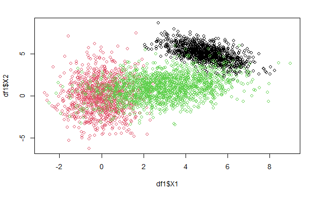

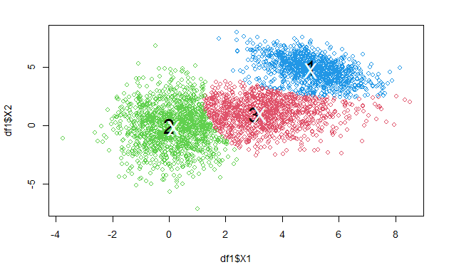

[figure not shown]

```r
external_validation(df1$color, df1$color_pred_2, summary_stats = T)
```

```
Error in external_validation(df1$color, df1$color_pred_2, summary_stats = T) :
  clusters should be a numeric vector
```

[figure not shown]

```r
plot_2d(data = x, clusters = df1$color_pred_2, centroids_medoids = gmm_2$centroids)

help(plot_2d)
```

```r
gmm_3$centroids
gmm_3$covariance_matrices
head(gmm_3$Log_likelihood)
```

[output not shown]

```r
x = subset(df, select=-c(color))
opt_gmm = Optimal_Clusters_GMM(x, max_clusters = 10, criterion = "BIC",
                               dist_mode = "eucl_dist", seed_mode = "random_subset",
                               plot_data = T)


help(Optimal_Clusters_GMM)
```

[output not shown]

```r
help(Silhouette_Dissimilarity_Plot)

data(soybean)

dat = soybean[, -ncol(soybean)]

cm = Cluster_Medoids(dat, clusters = 5, distance_metric = 'jaccard_coefficient')

plt_sd = Silhouette_Dissimilarity_Plot(cm, silhouette = TRUE)
```

[output not shown]

In the package ClusterR there are 3 different datasets: - dietary_survey_IBS: Synthetic data using a dietary survey of patients with irritable bowel syndrome. - mushroom: The mushroom data - soybean: The soybean (large) data set from the UCI repository

*dietary_survey_IBS* contains synthetic data generated using the mean and standard deviation of data used in the paper “A dietary survey of patients with irritable bowel syndrome”.

```r
help(dietary_survey_IBS)
```

It contains 400 rows and 43 columns.

“class” is the target column. Its values are O and 1, with 0 meaning healty and 1 meaning IBS-positive.

The other 42 columns are numeric and can be used as predictors.

```r
dim(dietary_survey_IBS)

colnames(dietary_survey_IBS)

unique(dietary_survey_IBS$class)

head(dietary_survey_IBS)
```

```r
pca_dat = stats::princomp(dietary_survey_IBS)$scores[, 1:2]
plot(pca_dat, col=dietary_survey_IBS$class + 1)
```

[output not shown]

```r
help(dietary_survey_IBS)
help(mushroom)
help(soybean)
```

*mushroom* includes descriptions of hypothetical samples corresponding to 23 species of gilled mushrooms in the Agaricus and Lepiota Family (pp. 500-525).

Each species can either be edible or poisonous. The Guide clearly states that there is no simple rule for determining the edibility of a mushroom; no rule like ‘leaflets three, let it be’ for Poisonous Oak and Ivy. For simplicity the unknown targets are marked as poisounous.

```r
help(mushroom)
```

It contains 8124 rows and 23 columns.

“class” is the target column. Its values are “p” and “e”, with “p” meaning poisounous (or unknown) and e meaning “edible”.

The other 22 columns contain one character each and can be used as predictors.

```r
dim(mushroom)

colnames(mushroom)

unique(mushroom$class)

head(mushroom)
```

```r
X = mushroom[1:1000, -1]

y = as.numeric(mushroom[1:1000, 1])

gwd = FD::gowdis(X)

gwd_mat = as.matrix(gwd)

pca_dat = stats::princomp(gwd_mat)$scores[, 1:2]
plot(pca_dat, col=y)
```

[output not shown]